# Illustration of how Gerlach’s method works for skewed data

These R scripts perfom simulations (“Case with distribution skew”) in Katahira et al. (Distribution of personality: types or skew?; Commentary: A robust data-driven approach identifies four personality types across four large data sets).

## Preparation

Install the required package (if not yet) by the following commands.

```r
install.packages("tidyverse")
install.packages("sn")
install.packages("reticulate")
install.packages("mixtools")
install.packages("ks")
install.packages("fields")
install.packages("mvtnorm")
```

Also, please install Python to use scikit-learn library via reticulate library. (We recommend Anaconda dibribution https://www.anaconda.com/ , which contains scikit-learn library.)

ref: https://rstudio.github.io/reticulate/

## Load library

```r
library(tidyverse)
library(reticulate)
library(sn)
library(mixtools)
library(ks)     # for kernel density estimation
library(fields) # for image.plot
library(mvtnorm)
```

## Synthesize data

First, samples are drawn from two independent skew-normal ditributions.

```r
set.seed(1)

N <- 100000  # number of samples

# draw samples from univariate skew normal
x1 <- rsn(n = N, dp=c(-1, 1, 4))
x2 <- rsn(n = N, dp=c(-1, 1, -4))

dat <- cbind(x1,x2)
```

Plot the samples.

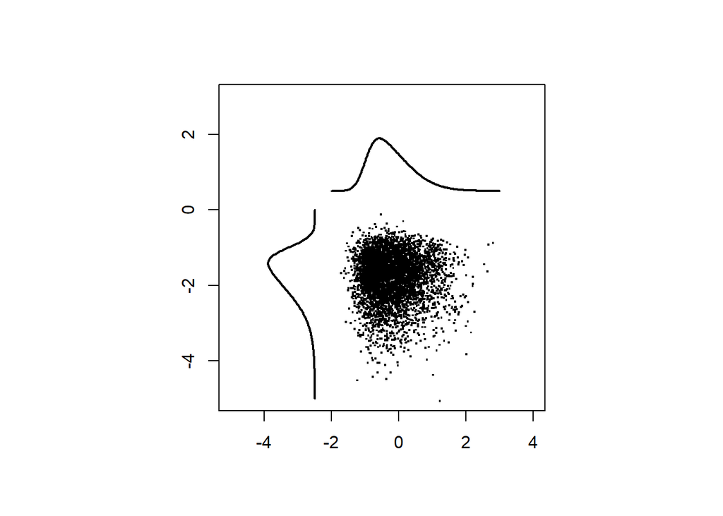

```r
par(pty = "s")

nplot <- 5000 # number of samples to plot

plot(c(-5,4),c(-5,3),type="n",ann=F)

x1seq <- seq(-2, 3, length=201)
x2seq <- seq(-5, 0, length=201)

# draw marginals
pd1 <- dsn(x1seq, dp=c(-1, 1, 4))
pd2 <- dsn(x2seq, dp=c(-1, 1, -4))
lines(x1seq, pd1 * 2 + 0.5,lwd = 2)
lines(-pd2 * 2 - 2.5, x2seq,lwd = 2)

# scatter plot
points(x1[1:nplot],
       x2[1:nplot],
       pch=".",cex = 2)
```

Rotate the samples by 45 degrees.

```r
# rotation matrix
theta <- -pi/4
R <- matrix(c(cos(theta), -sin(theta),
              sin(theta), cos(theta)),
            2,2,byrow = T)

df_data <- data.frame(scale(dat) %*% t(R))
```

Plot the rotated data.

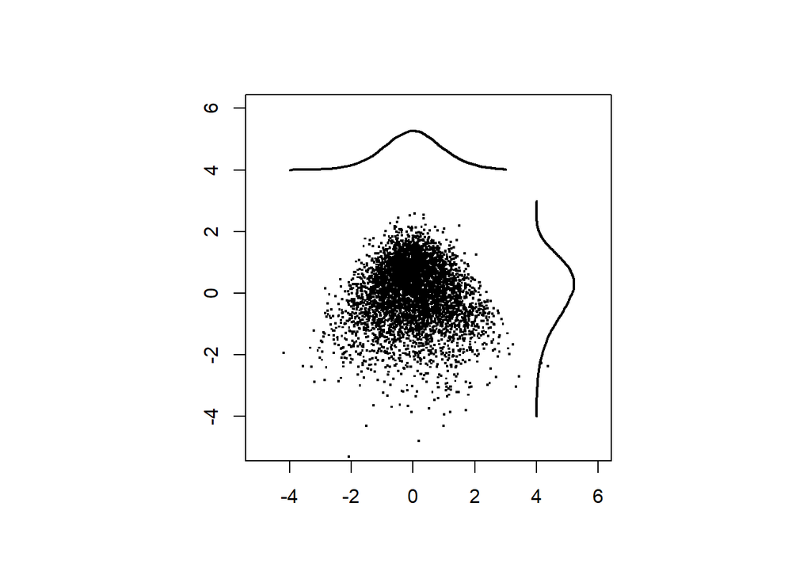

```r
par(pty = "s")
plot(c(-5,6),c(-5,6),type="n",ann=F)

# draw marginals
d1 <- density(df_data$X1,from = -4, to = 3)
d2 <- density(df_data$X2,from = -4, to = 3)
lines(d1$x, d1$y*3+4,
      xlim=c(-6,6), ylim=c(0,0.3),lwd = 2)
lines(d2$y*3+4, d2$x,
      xlim=c(-6,6), ylim=c(0,0.3),lwd = 2)

# scatter plot
points(df_data$X1[1:nplot],
       df_data$X2[1:nplot],
       pch=".",cex = 2)
```

Plot shuffuled data.

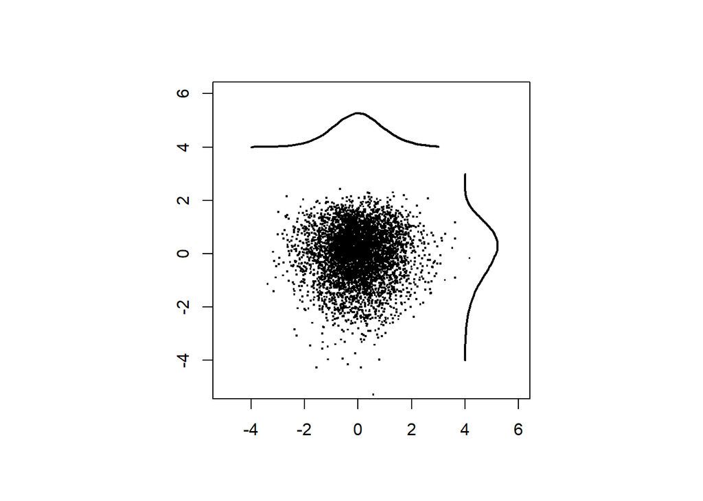

```r
xdim <- ncol(df_data)
x.shuffeled <- matrix(0,N,xdim)

for (idx in 1:xdim)
  x.shuffeled[,idx] <- df_data[sample(N),idx]

par(pty = "s")
plot(c(-5,6),c(-5,6),type="n",ann=F)
points(x.shuffeled[1:nplot,1],
       x.shuffeled[1:nplot,2],
       pch=".",cex = 2)

d1 <- density(x.shuffeled[,1],from = -4, to = 3)
d2 <- density(x.shuffeled[,2],from = -4, to = 3)
lines(d1$x, d1$y*3+4,
      xlim=c(-6,6), ylim=c(0,0.3),lwd = 2)
lines(d2$y*3+4, d2$x,
      xlim=c(-6,6), ylim=c(0,0.3),lwd = 2)
```

## Fitting GMMs

Following Gerlach et al., we choose initial parameters of GMMs from the results of K-means. If you select “random” initialization, the estimates will be different, suggesting that the GMM estimation for data of this kind is not robust.

```r
sk <- reticulate::import(module = "sklearn")

klist <- 1:20 # number of components
n.rep <- 10   # number of runs from different intialization

biclog <- numeric(length(klist)) # to store BIC
gmm_list <- list()               # to store GMM

for (idxk in klist){
  K <- klist[idxk]
  ll.min <- -Inf

  cat("\nfitting GMM... K =", K)

  for (idxrun in 1:n.rep) {
    cat("*")

    initpar <- "kmeans"

    ## uncomment if you want to include random intialization
    # if (idxrun < n.rep*0.5)
    #   initpar <- "kmeans"
    # else
    #   initpar <- "random"

    sk_gmm <- sk$mixture$GaussianMixture
    gmm <- sk_gmm(as.integer(K),
                  n_init = 1L,
                  max_iter = 200L,
                  init_params = initpar)
    gmm$fit(df_data)

    ll <- gmm$lower_bound_

    if (ll > ll.min) {
      ll.min <- ll
      cluster.center <- data.frame(gmm$means_)
      names(cluster.center) <- names(df_data)
      biclog[idxk] <- gmm$bic(df_data)
      gmm_list[[idxk]] <- gmm
    }
  }
}
```

```
##
## fitting GMM... K = 1**********
## fitting GMM... K = 2**********
## fitting GMM... K = 3**********
## fitting GMM... K = 4**********
## fitting GMM... K = 5**********
## fitting GMM... K = 6**********
## fitting GMM... K = 7**********
## fitting GMM... K = 8**********
## fitting GMM... K = 9**********
## fitting GMM... K = 10**********
## fitting GMM... K = 11**********
## fitting GMM... K = 12**********
## fitting GMM... K = 13**********
## fitting GMM... K = 14**********
## fitting GMM... K = 15**********
## fitting GMM... K = 16**********
## fitting GMM... K = 17**********
## fitting GMM... K = 18**********
## fitting GMM... K = 19**********
## fitting GMM... K = 20**********
```

### Plot the locations of Gaussian components

Define function for ploting cluster centers.

```r
plot.cluster.center <- function(cluster.center) {
  n.cluster <- nrow(cluster.center)
  for (idxc in 1:n.cluster) {
    points(x = cluster.center[idxc,1],
           y = cluster.center[idxc,2],
           pch = 4, # "+"
           cex = 1.5,
           col="red", lwd=2)
  }
}
```

Scatter plot of data with ellipses of Gaussian components.

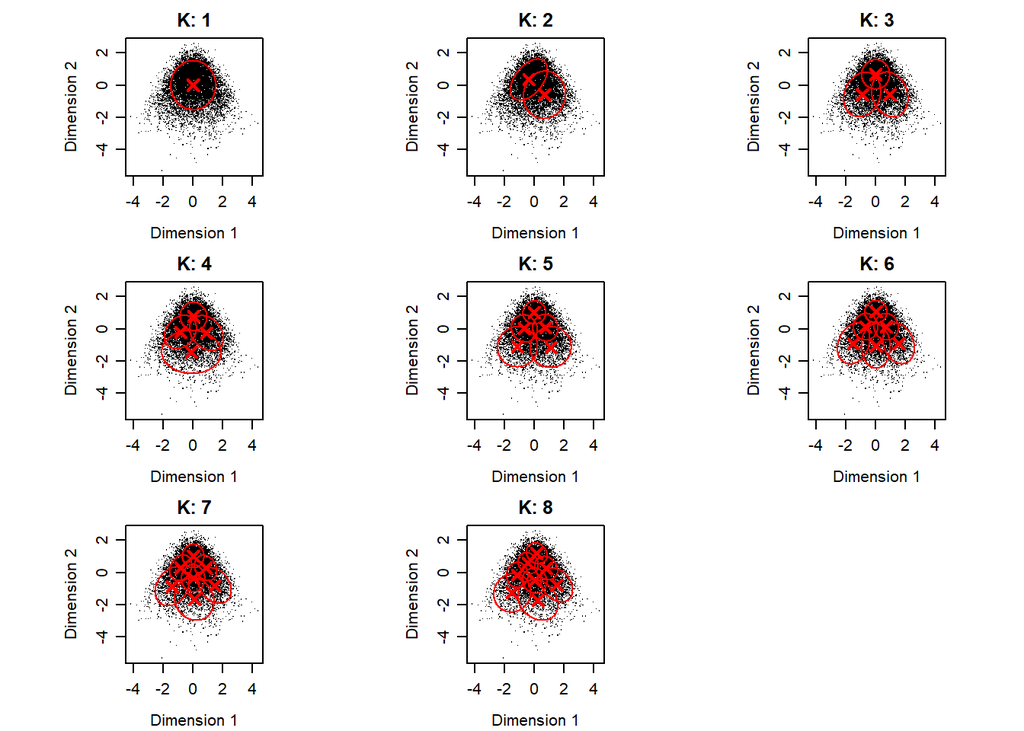

```r
par(mfrow=c(3,3), pty = "s",
    mar=c(3.5, 3.5, 2, 1), mgp=c(2.4, 0.8, 0))

for (idxk in 1:8) {
  plot(df_data$X1[1:10000],
       df_data$X2[1:10000],"p",
       pch = ".",
       xlab="Dimension 1",
       ylab="Dimension 2",
       main=paste("K:", idxk))

  for (idxc in 1:idxk) {
    mixtools::ellipse(mu=gmm_list[[idxk]]$means_[idxc,],
            sigma=gmm_list[[idxk]]$covariances_[idxc,,],
            alpha = 1-.6827,  # 1 sigma
            npoints = 250, col="red")
  }
  plot.cluster.center(gmm_list[[idxk]]$means_)
}
```

### Plot BIC

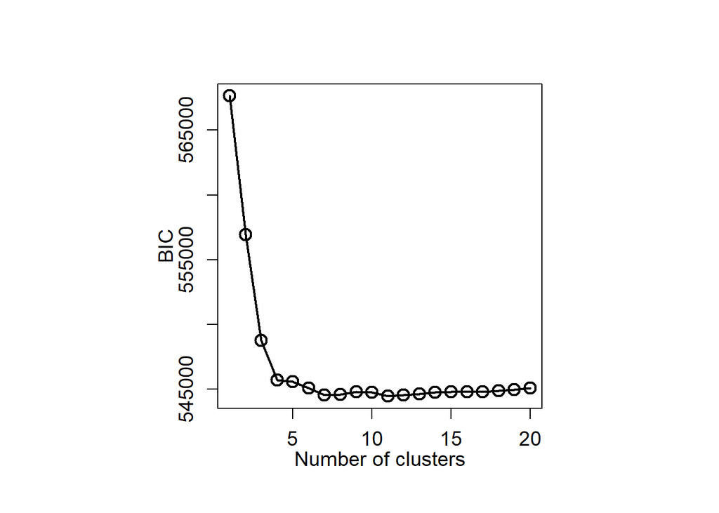

```r
par(mgp=c(2, 1, 0), pty = "s")
plot(klist,biclog, type = "o",
     xlab = "Number of clusters", ylab = "BIC", lwd = 2,
     cex      = 1.5,
     cex.lab  = 1.2,
     cex.axis = 1.2)
```

We select the GMM with seven components (K=7).

```r
K.selected <- 7
```

## Evaluate clusters

### Density estimation

Define a function ‘estkd’ for density estimation of original data and shuffled data

```r
estkd <- function(x, xmin, xmax,
                  n.shuffle = 1000,
                  p.threshold = 0.01,
                  density.threhold = 0.05,
                  enrichment.threshold = 1.25) {

  xdim <- ncol(x) # number of latent factors
  N <- nrow(x)

  # kernel density estiamtion of original data

  Hpi <- ks::Hpi.diag(x = x, nstage = 2)

  k <- ks::kde(x = x,verbose = TRUE, H = Hpi,
               xmin = xmin,
               xmax = xmax)
  density.original <- k$estimate

  # exceedance of original density
  count_exceedance <- array(0, dim(density.original))

  # shuffled data
  cat("Density estimation for shuffled data...")
  cat("\n 1/",n.shuffle, "\n")

  for (idxs in 1:n.shuffle) {
    if (idxs %% 100 == 0)
      cat(idxs, " ")

    fsc.s.shuffeled <- matrix(0,N,xdim)

    for (idx in 1:xdim)
      fsc.s.shuffeled[,idx] <- x[sample(nrow(x)),idx]

    k.shuffle <- ks::kde(x = fsc.s.shuffeled, H = Hpi,
                         xmin = xmin,
                         xmax = xmax)

    count_exceedance <- count_exceedance +
      as.numeric(density.original < k.shuffle$estimate)

    if (idxs == 1)
      density.sum <- k.shuffle$estimate
    else
      density.sum <- density.sum + k.shuffle$estimate
  }

  d.shuffle <- density.sum / n.shuffle

  p.value <- count_exceedance / n.shuffle
  sig.region <- (p.value < p.threshold &
                   density.original > density.threhold &
                   density.original / d.shuffle > enrichment.threshold)

  storage.mode(sig.region) <- "numeric"

  list(k = k, # output of kde for original data
       d.original = density.original,
       count.exceedance = count_exceedance,
       d.shuffle = d.shuffle,
       p.value = p.value,
       sig.region = sig.region)
}
```

Prepare for plot.

```r
xmin <- c(min(-5,min(df_data)),min(-5,min(df_data)))
xmax <- c(max(5,max(df_data)),max(4,max(df_data)))

# calculate density
ret <- estkd(df_data, xmin, xmax,
             n.shuffle = 1000,
             density.threhold = 0)
```

```
## Density estimation for shuffled data...
##  1/ 1000
## 100  200  300  400  500  600  700  800  900  1000
```

```r
zlim_max <- max(ret$d.original)
zlim_min <- 0
cex.main <- 1.8

kd <- ret$k
```

### Scatter plot of original data and density plot

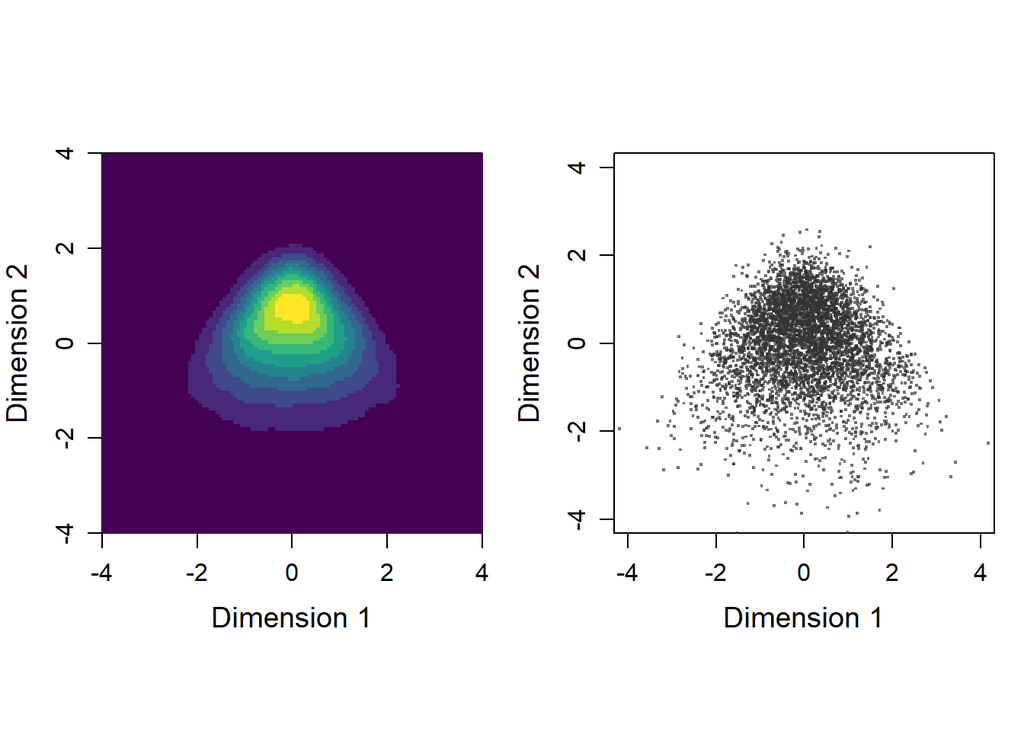

```r
par(mfrow=c(1,2), pty = "s")
par(mar=c(3.5, 3.5, 2, 1), mgp=c(2.4, 0.8, 0))

xlim <- c(-4, 4)
ylim <- c(-4, 4)

# Panel 1 (density)
image(kd$estimate,
      x = kd$eval.points[[1]],
      y = kd$eval.points[[2]],
      xlab = "Dimension 1",
      ylab = "Dimension 2",
      xlim = xlim,
      ylim = ylim,
      col = viridis::viridis(10),
      cex.axis = 1,
      cex.lab = 1.2)

# Panel 2 (scatter plot)
plot(c(-4,4),c(-4,4),type="n",
     xlab = "Dimension 1",
     ylab = "Dimension 2",
     xlim = xlim,
     ylim = ylim,
     cex.axis = 1,
     cex.lab = 1.2)

points(df_data$X1[1:nplot],
       df_data$X2[1:nplot],
       col = rgb(0.2,0.2,0.2,alpha=0.7),
       pch=".",
       cex = 2)
```

### Plot densities of original data and shuffled data

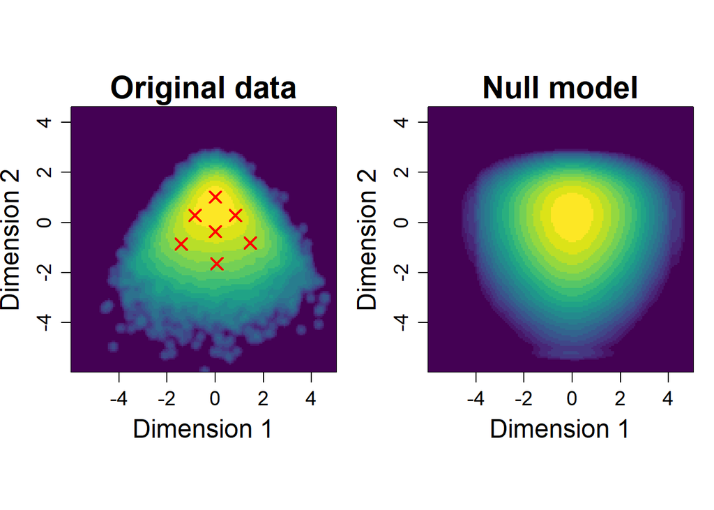

```r
par(mfrow=c(1,2), pty = "s")
par(mar=c(3.5, 3.5, 2, 1), mgp=c(2.4, 0.8, 0))

log.density.original <- log(pmax(kd$estimate,   0.00001))
log.density.shuffle <-  log(pmax(ret$d.shuffle, 0.00001))

# Panel 1 (original data)
image(log.density.original,
      x = kd$eval.points[[1]],
      y = kd$eval.points[[2]],
      xlab = "Dimension 1", ylab = "Dimension 2",
      col = viridis::viridis(20),
      cex.axis = 1.2, cex.lab = 1.5,
      cex.sub = 1.2)

plot.cluster.center(gmm_list[[K.selected]]$means_)

title(main = sprintf("Original data"),
      cex = 1.2, cex.main = cex.main)

# Panel 2 (shuffled data)
image(log.density.shuffle,
      x = kd$eval.points[[1]],
      y = kd$eval.points[[2]],
      xlab = "Dimension 1", ylab = "Dimension 2",
      col = viridis::viridis(20),
      cex.axis = 1.2, cex.lab = 1.5,
      cex.sub = 1.2)
title(main = sprintf("Null model"),
      cex = 1.5, cex.main = cex.main)
```

### Plot enrichment

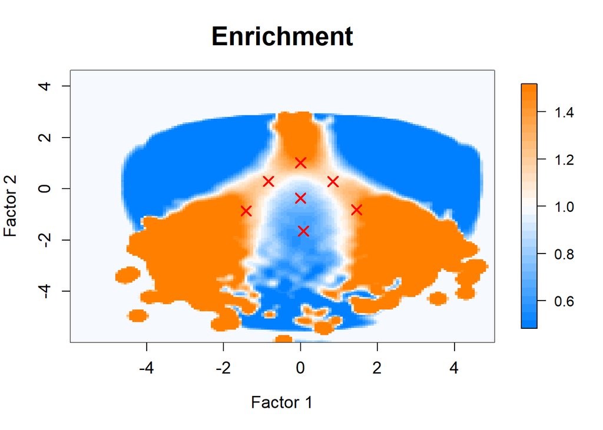

```r
color.palette = colorRampPalette(
  c("#0080ff","white","#ff8000"))
er <- exp(log.density.original - log.density.shuffle)
par(pty="s")
image.plot(kd$eval.points[[1]],
           kd$eval.points[[2]],
           pmax(pmin(er,1.5),0.5),
           col = color.palette(30),
           zlim = c(0.5,1.5),
           xlab="Factor 1", ylab="Factor 2",
           cex.axis = 1.2, cex.lab = 1.2,cex.sub = 1.2
           )
plot.cluster.center(gmm_list[[K.selected]]$means_)
title(main = sprintf("Enrichment"),
      cex = 1.8, cex.main = cex.main)
```

### p-value and enrichment thresholded

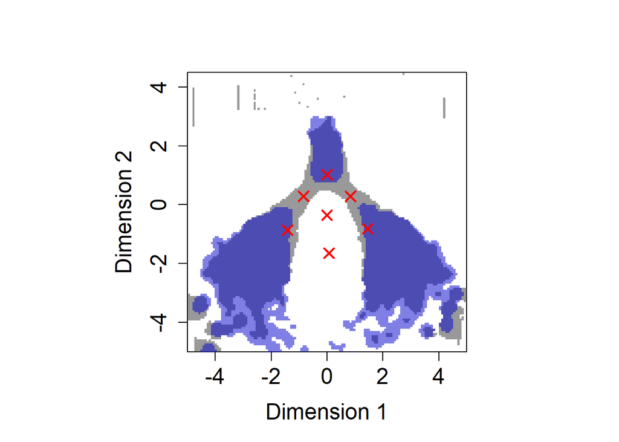

```r
par(pty="s")
# p-value (p < .01)
image(kd$eval.points[[1]],
      kd$eval.points[[2]],
      z = (ret$p.value < .01),
      col = c( rgb(0, 0, 0, alpha=0.0),
               rgb(0.2,0.2, 0.2, alpha=0.5)),
      xlim = c(-5,5),
      ylim = c(-5,4.5),
      zlim = c(0,1),
      xlab = "Dimension 1", ylab = "Dimension 2",
      cex.axis = 1.5, cex.lab = 1.5
)
# enrichment (> 1.25)
image(kd$eval.points[[1]],
           kd$eval.points[[2]],
           z = exp(log.density.original - log.density.shuffle) > 1.25,
           col = c( rgb(0, 0, 0, alpha=0.0),
                    rgb(0, 0, 0.8, alpha=0.5)),
           zlim = c(0,1),
      add = T
)
plot.cluster.center(gmm_list[[K.selected]]$means_)
```

### Plot 3d density of GMM and and scatter disribution with GMM contours

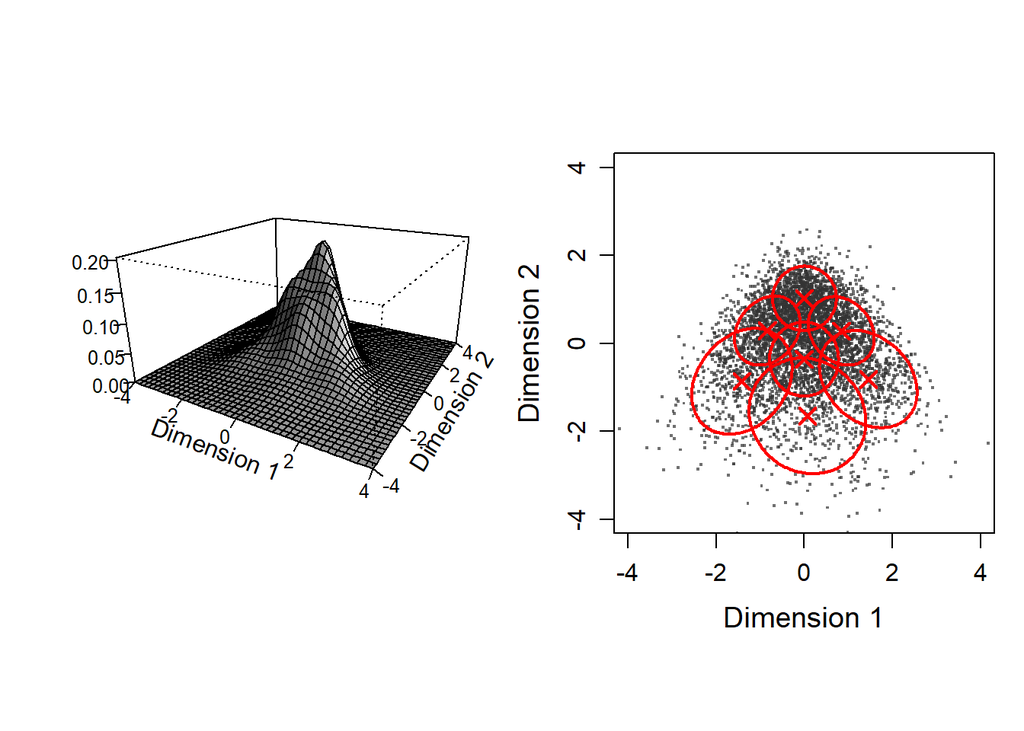

```r
par(mfrow=c(1,2), pty = "s")
par(mar=c(3.5, 3.5, 2, 1), mgp=c(2.4, 0.8, 0))

x <- seq(-4,4, by =0.2)
y <- seq(-4,4, by =0.2)
grid <- expand.grid(x1 = x, x2 = y)

d <- matrix(0, nrow = length(x),
            ncol = length(y))

for (idxc in 1:klist[K.selected]) {
  d <- d + gmm_list[[K.selected]]$weights_[idxc] *
    matrix(dmvnorm(
      cbind(grid$x1, grid$x2),
      mean = gmm_list[[K.selected]]$means_[idxc,],
      sigma = gmm_list[[K.selected]]$covariances_[idxc,,]),
      nrow = length(x),
      ncol = length(y))
}
persp(x, y, d,
      theta=30,
      phi=20, expand=0.5,
      ticktype="detailed",
      ltheta = 120, shade = 0.75,
      xlab = "Dimension 1",
      ylab = "Dimension 2",
      xlim = xlim,
      ylim = ylim,
      zlab = "",
      cex.axis = 0.8
      )

plot(df_data$X1[1:nplot],
     df_data$X2[1:nplot],
     "p",
     col = rgb(0.2,0.2,0.2,alpha=0.7),
     pch=".",
     xlim = xlim,
     ylim = ylim,
     xlab="Dimension 1",
     ylab="Dimension 2",
     cex = 2,
     cex.axis = 1,
     cex.lab = 1.2)

for (idxc in 1:klist[K.selected]) {
  mixtools::ellipse(mu=gmm_list[[K.selected]]$means_[idxc,],
                    sigma=gmm_list[[K.selected]]$covariances_[idxc,,],
                    alpha = 1-.6827, # 1 sigma
                    npoints = 250, col="red", lwd =2)
}
plot.cluster.center(gmm_list[[K.selected]]$means_)
```

# Evaluate each cluter center

Define function for evaluate each cluter center

```r
# Input：
#    x, # data matrix (factor scores) (respondent x dimension)
#    c.center, cluster center matrix (cluster center x dimension)
#    n.shuffle = 1000  number of shuffles
#
# Output:
#    $d.original # density of original data
#    $d.null     # mean density of null model
#    $p.value    # p-value
#    $enrichment # = d.original/d.null
eval_component <- function(x, c.center, n.shuffle = 1000) {

  xdim <- ncol(x)
  N <- nrow(x)
  n.component <- nrow(c.center)

  p.value <- numeric(n.component)
  enrichment <- numeric(n.component)

  cat("Bandwidth selection...\n")
  Hpi <- ks::Hpi.diag(x = x[1:min(N,1000),],
                      nstage = 2)
  cat("kernel dinsity estimation for original data...\n")
  k <- ks::kde(x = x, H = Hpi,
               eval.points = c.center,
               binned = FALSE)
  density.original <- k$estimate

  density.shuffle <- matrix(0, n.shuffle, nrow(c.center))

  cat("kernel dinsity estimation for shuffled data...\n")
  for (idxs in 1:n.shuffle) {
    if (idxs %% 10 == 1)
      cat("=")

    sc_shuffeled <- apply(x, MARGIN = 2, sample)

    k <- ks::kde(x = sc_shuffeled, H = Hpi,
                 eval.points = c.center,
                 binned = TRUE) # should be FALSE if the number of dimension >= 4

    density.shuffle[idxs,] <- k$estimate
  }
  cat("\n")

  density.null <- colMeans(density.shuffle)

  for (idx in 1:n.component) {

    p.value[idx] <- sum(density.original[idx] < density.shuffle[,idx]) / n.shuffle

    enrichment[idx] <- density.original[idx] /
      density.null[idx]

    d.null.mean <- mean(density.shuffle[,idx])
  }

  list(d.original = density.original,
       d.null = density.null,
       p.value = p.value,
       enrichment = enrichment )
}
```

Evaluate clusters (Gaussian components).

```r
res_ec <- eval_component(df_data,
               gmm_list[[K.selected]]$means_)
```

```
## Bandwidth selection...
## kernel dinsity estimation for original data...
## kernel dinsity estimation for shuffled data...
## ====================================================================================================
```

```r
# FALSE: not meaningful, TRUE: meaningful
flg_meaningful <- (res_ec$p.value < 0.01 &
                     res_ec$enrichment > 1.25)

# 1: not meaningful,2: meaningful
idx_meaningful <- flg_meaningful + 1
```

Calculate the fraction of samples classified into each cluster.

```r
cluster_labels <- apply(gmm_list[[K.selected]]$predict_proba(df_data),1,which.max)

(tb <- table(cluster_labels))
```

```
## cluster_labels
##     1     2     3     4     5     6     7
##  4732 16418 16713 16591  8884  9203 27459
```

```r
cat("Fraction of samples classified into one of the meaningful clusters:",
    sum(tb[flg_meaningful])/sum(tb))
```

```
## Fraction of samples classified into one of the meaningful clusters: 0.45546
```

# Plot clusters with meaningful clusters being colored differently

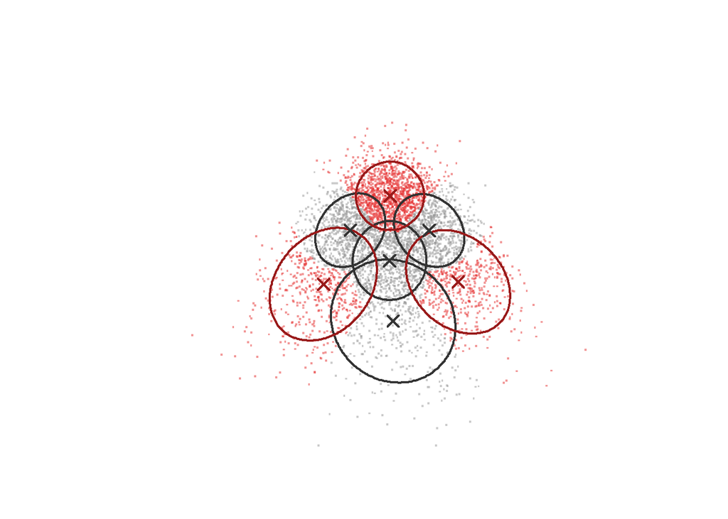

```r
par(pty = "s")
par(mar=c(3.5, 3.5, 2, 1), mgp=c(2.4, 0.8, 0))

col.ellipse <- c("gray20",rgb(0.6,0.1,0.1,alpha=1))

colpoint <- c(rgb(0.6,0.6,0.6,alpha=0.5),
              rgb(0.9,0.2,0.2,alpha=0.5) # meaningful cluster
              )

plot(df_data$X1[1:nplot],
     df_data$X2[1:nplot],
     "p",
     col = colpoint[idx_meaningful[cluster_labels[1:nplot]]],
     pch=".", bty="n", xaxt="n", yaxt="n",
     xlab = "", ylab = "",
     xlim = xlim, ylim = ylim,
     cex = 2, cex.axis = 1, cex.lab = 1.2)

for (idxc in 1:klist[K.selected]) {
  mixtools::ellipse(mu=gmm_list[[K.selected]]$means_[idxc,],
                    sigma=gmm_list[[K.selected]]$covariances_[idxc,,],
                    alpha = 1-.6827, # 1 sigma
                    npoints = 250, col=col.ellipse[idx_meaningful[idxc]], lwd =2)
}

plot.cluster.col <- function(cluster.center, col) {
  idxk <- nrow(cluster.center)
  for (idxc in 1:idxk) {
    points(x = cluster.center[idxc,1],
           y = cluster.center[idxc,2],
           pch = 4, # "+"
           cex = 1.5,
           col=col[[idxc]], lwd=2)
  }
}

plot.cluster.col(gmm_list[[K.selected]]$means_, col.ellipse[idx_meaningful])
```